# Relatório BI

## Autores

- Turma: CNI61
- Grupo: G01
- Autores
  - 20200034 Atanásio Mazita
  - 20210081 Catarina Duarte
  - 20210085 Diogo Leitão
  - 20210083 Pedro Guedes
  - 20211135 Ricardo Peralta

## Introdução

A empresa comercializa equipamentos de ciclismo, bicicletas, acessórios e vestuário adequados à prática do desporto.  
O relatório incide sobre o período que vai de 01-07-2016 a 31-07-2019.  
O portefólio da empresa é constituído 397 produtos, divididos em 4 categorias e 37 subcategorias.  
As vendas repartem-se por 10 territórios.

De seguida apresenta-se uma breve descrição dos dados demográficos dos clientes, e dados para os diferentes departamentos da empresa.

## Departamento Marketing

Abaixo estão representados vários gráficos que permitem ao Departamento de Marketing tomar decisões informadas e estratégicas.

### Perfil dos clientes

- **Estado Civil**

No pie chart abaixo, podemos perceber que cada secção do gráfico representa a percentagem da população que corresponde a uma categoria específica de estado civil. Neste caso específico podemos distinguir entre Casados e Solteiros.

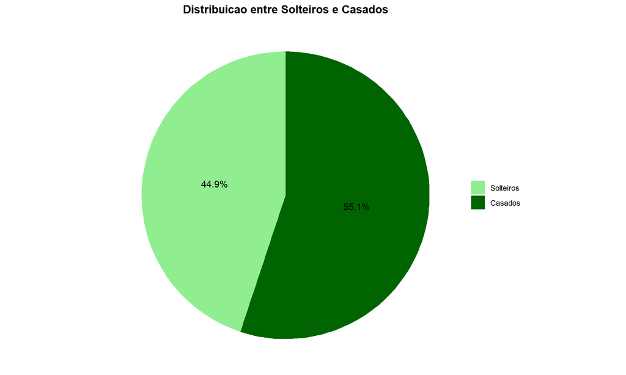

- O gráfico seguinte está subdivido em 6 gráficos - um por cada país para o qual a empresa vende - e demonstra a quantidade de filhos por cliente.

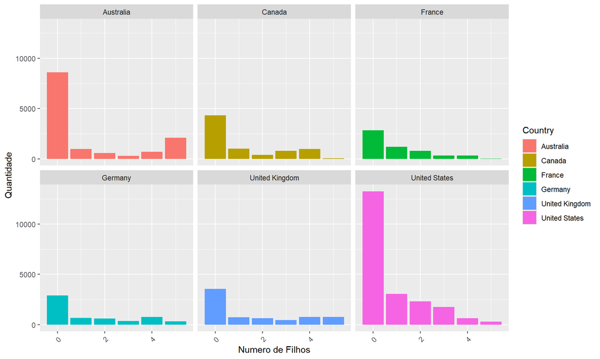

- **Profissão do cliente**

No gráfico abaixo apresentado podemos visualizar a distribuição da quantidade de clientes em diferentes profissões.

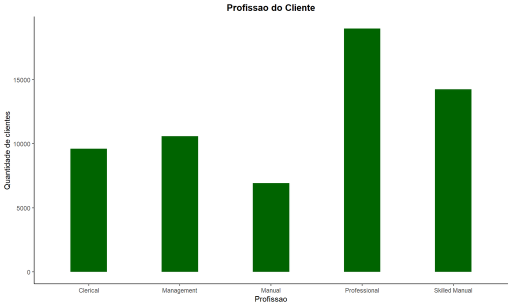

- **Género por País**

É representado abaixo um gráfico de barras através do qual se pretende demonstrar a distribuição de género por país.

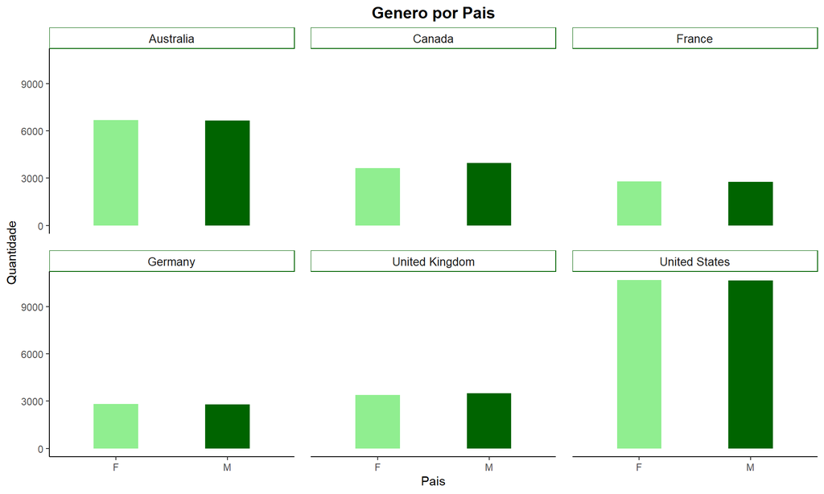

- **Numero de Vendas distribuidas por Profissão**

O gráfico mostra a distribuição percentual das vendas entre as diferentes profissões dos clientes da empresa.

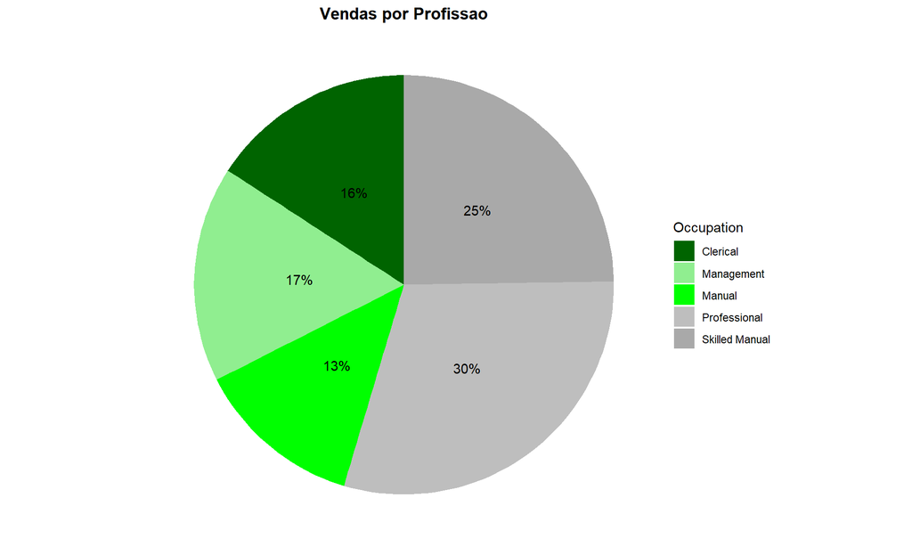

## Departamento de Vendas

Nos gráficos que se seguem estão representados dados a ser partilhados com o departamento de vendas, com vista a um aumento de desempenho por parte da equipa..

- **Vendas por Trimestre**

No gráfico abaixo estão representadas as vendas por trimestre, divididas pelos 4 anos que o relatório contempla.

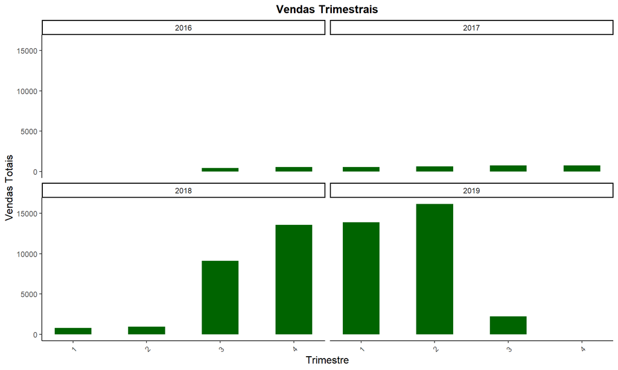

- **Categorias mais vendidas por país**

No seguinte gráfico estão representadas as categorias de produto mais vendidas por país.

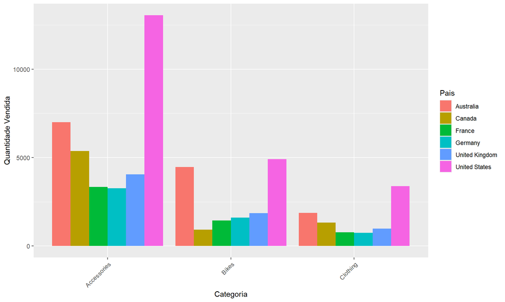

- **Frequencia de produtos**

| ProductName | Frequency |
| --- | --- |
| All-Purpose Bike Stand | 1 |
| AWC Logo Cap | 3 |
| Bike Wash - Dissolver | 1 |
| Cable Lock | 1 |

## Departamento Financeiro

As informações que se seguem têm como objetivo providenciar informação para o departamento financeiro.

- **Vendas ao longo do tempo**

O gráfico que se segue demonstra a tendência das vendas ao longo dos anos.

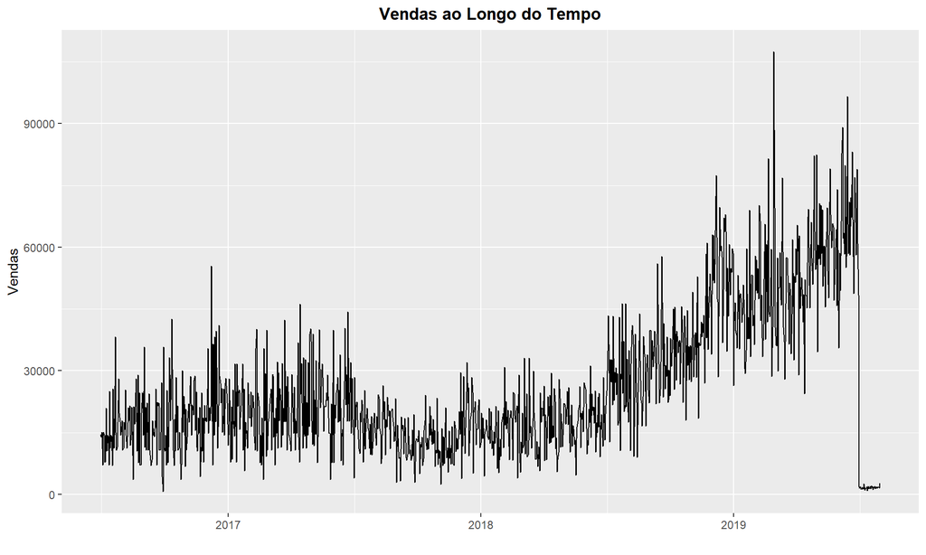

- **Rentabilidade por Produto**

| ProductName | total_sales |
| --- | --- |
| Mountain-200 Black, 46 | 1,373,470 |
| Mountain-200 Black, 42 | 1,363,142 |
| Mountain-200 Silver, 38 | 1,339,463 |
| Mountain-200 Silver, 46 | 1,301,100 |

[figure not shown]

# Apêndice

## 1. Dicionário do *data mart*

### dimensão `calendar`

- **ID** : chave primária (*numeric*)
- **Date** : data (dd/mm/yyyy) da transacção (*date*)
- **DayNumberOfWeek** : dia da semana (*num*)
- **DayName** : nome do dia da semana (*character*)
- **MonthName** : nome do mês (inglês) (*chr*)
- **MonthNumberofYear** : numero do mês (*num*)
- **DayNumberOfYear** : numero do dia do ano (*num*)
- **WeekNumberOfYear** : numero da semana do ano (*num*)
- **CalendarQuarter** : trimestre do ano (*num*)
- **CalendarYear** : ano (*num*)
- **DayNumberOfMonth** : dia do mês (*num*)

### dimensão `customers`

- **CustomerKey** : chave primária número de cliente (*num*)
- **GeographyKey** : código do país (*num*)
- **Name** : nome do cliente (*character*)
- **BirthDate** : data de nascimento (*num*)
- **MaritalStatus** : estado civil (*character*)
- **Gender** : género (*character*)
- **YearlyIncome** : remuneração anual (*num*)
- **NumberChildernAtHome** : número de filhos (*num*)
- **Occupation** : profissão (*character*)
- **HouseOwnerFlag** : proprietério de imóvel? (*num*)
- **NumberCarsOwned** : número de carros (*num*)
- **AddressLine** : morada (*character*)
- **Phone** : número de telefone (*num*)
- **DateFirstPurchase** : data da primeira compra (*date*)

### dimensão `factSales`

- **OrderDate** : data de encomenda (*date*)
- **OrderDateKey** : chave primária (*num*)
- **ProductKey** : código de produto (*num*)
- **CustomerKey** : código de cliente (*num*)
- **SalesTerritoryKey** : código de território (*num*)
- **SalesOrderNumber** : referência da encomenda (*num*)
- **SalesOrderLineNumber** : Número de referências na encomenda (*num*)
- **OrderQuantity** : Quantidade da encomenda (*num*)
- **UnitPrice** : Preço unitário (*num*)
- **ProductSantardCost** : Custo padrão do produto (*num*)
- **SalesAmount** : Quantidade de vendas (*num*)
- **TaxAmount** : Valor de imposto (*num*)
- **Freight** : Frete (*num*)
- **RegionMonthID** : Mês e região da encomenda (__character_num_)

### dimensão `products`

- **ProductKey** : Código do produto (*num*)
- **ProductSubCategoryKey** : Código da sub-categoria do produto (*num*)
- **ProductName** : Nome do produto (*character*)
- **StandardCost** : Custo padrão (*num*)
- **Color** : Cor (*character*)
- **SafetyStockLevel** : Nível de stock de segurança (*num*)
- **ListPrice** : Preço de tabela (*num*)
- **Size** : Tamanho (*num*)
- **DaysToManufacture** : Tempo de produção (*num*)
- **DealerPrice** : Preço de revenda (*num*)
- **Class** : Classe (*character*)
- **ModelName** : Nome do modelo (*character*)
- **Description** : Descrição (*character*)
- **Status** : Estado (*character*)
- **SubCategory** : Sub-categoria (*character*)
- **Category** : Categoria (*character*)
- **StartDate** : Data de início (*date*)
- **EndDate** : Data final (*date*)

### dimensão `productCategory`

- **ProductCatergoryKey** : Código de categoria do produto (*num*)
- **EnglishProductCategoryName** : Nome da categoria do produto ENG (_character)
- **SpanishProductCategoryName** : Nome da categoria do produto ESP (_character)
- **FrenchProductCategoryName** : Nome da categoria do produto FR (_character)

### dimensão `productSubCategory`

- **ProductCategoryKey** : Código de categoria do produto (*num*)
- **ProductSubCategoryKey** : Código da sub-categoria do produto (*num*)
- **EnglishProductSubCategoryName** : Nome da sub-categoria do produto ENG (*character*)
- **SpanishProductSubCategoryName** : Nome da sub-categoria do produto Esp (*character*)
- **FrenchProductSubCategoryName** : Nome da sub-categoria do produto FR (*character*)

### dimensão `territory`

- **TerritoryKey** : Código de território (*num*)
- **Region** : Região (*character*)
- **Country** : País (*character*)
- **Group** : Grupo (*character*)

### dados `calendar`

| ID | Date | DayNumberOfWeek | DayName | MonthName | MonthNumberOfYear | DayNumberOfYear | WeekNumberOfYear | CalendarQuarter | CalendarYear | DayNumberOfMonth |
| --- | --- | --- | --- | --- | --- | --- | --- | --- | --- | --- |
| 1 | 2016-07-01T00:00:00Z | 6 | Friday | July | 7 | 183 | 27 | 3 | 2016 | 1 |
| 2 | 2016-07-02T00:00:00Z | 7 | Saturday | July | 7 | 184 | 27 | 3 | 2016 | 2 |
| 3 | 2016-07-03T00:00:00Z | 1 | Sunday | July | 7 | 185 | 27 | 3 | 2016 | 3 |
| 4 | 2016-07-04T00:00:00Z | 2 | Monday | July | 7 | 186 | 28 | 3 | 2016 | 4 |
| 5 | 2016-07-05T00:00:00Z | 3 | Tuesday | July | 7 | 187 | 28 | 3 | 2016 | 5 |
| 6 | 2016-07-06T00:00:00Z | 4 | Wednesday | July | 7 | 188 | 28 | 3 | 2016 | 6 |
| 7 | 2016-07-07T00:00:00Z | 5 | Thursday | July | 7 | 189 | 28 | 3 | 2016 | 7 |
| 8 | 2016-07-08T00:00:00Z | 6 | Friday | July | 7 | 190 | 28 | 3 | 2016 | 8 |
| 9 | 2016-07-09T00:00:00Z | 7 | Saturday | July | 7 | 191 | 28 | 3 | 2016 | 9 |
| 10 | 2016-07-10T00:00:00Z | 1 | Sunday | July | 7 | 192 | 28 | 3 | 2016 | 10 |

[output cut: 90 more lines]